# Prix de rentes viagères genrés et unisexe

2025-05-15

```r
install.packages("StMoMo")
```

```r
install.packages("demography")
install.packages("ggplot2")
install.packages("HMDHFDplus")
library(forecast)
```

Chargement des packages

```r
library(demography)
#install.packages("StMoMo")  # à exécuter une seule fois
library(StMoMo)
library(forecast)
library(gnm)
```

Chargement des données

```r
CHEdata <- hmd.mx("CHE", username = "", password = "", label = "Switzerland")
str(CHEdata)
```

```
## List of 7
##  $ type  : chr "mortality"
##  $ label : chr "Switzerland"
##  $ lambda: num 0
##  $ year  : int [1:148] 1876 1877 1878 1879 1880 1881 1882 1883 1884 1885 ...
##  $ age   : int [1:111] 0 1 2 3 4 5 6 7 8 9 ...
##  $ pop   :List of 3
##   ..$ female: num [1:111, 1:148] 35215 33377 32094 32151 31640 ...
##   .. ..- attr(*, "dimnames")=List of 2
##   .. .. ..$ : chr [1:111] "0" "1" "2" "3" ...
##   .. .. ..$ : chr [1:148] "1876" "1877" "1878" "1879" ...
##   ..$ male  : num [1:111, 1:148] 35823 33636 32494 32638 32107 ...
##   .. ..- attr(*, "dimnames")=List of 2
##   .. .. ..$ : chr [1:111] "0" "1" "2" "3" ...
##   .. .. ..$ : chr [1:148] "1876" "1877" "1878" "1879" ...
##   ..$ total : num [1:111, 1:148] 71038 67014 64588 64788 63747 ...
##   .. ..- attr(*, "dimnames")=List of 2
##   .. .. ..$ : chr [1:111] "0" "1" "2" "3" ...
##   .. .. ..$ : chr [1:148] "1876" "1877" "1878" "1879" ...
##  $ rate  :List of 3
##   ..$ female: num [1:111, 1:148] 0.22666 0.03892 0.01801 0.01241 0.00917 ...
##   .. ..- attr(*, "dimnames")=List of 2
##   .. .. ..$ : chr [1:111] "0" "1" "2" "3" ...
##   .. .. ..$ : chr [1:148] "1876" "1877" "1878" "1879" ...
##   ..$ male  : num [1:111, 1:148] 0.2808 0.0358 0.0197 0.0126 0.0095 ...
##   .. ..- attr(*, "dimnames")=List of 2
##   .. .. ..$ : chr [1:111] "0" "1" "2" "3" ...
##   .. .. ..$ : chr [1:148] "1876" "1877" "1878" "1879" ...
##   ..$ total : num [1:111, 1:148] 0.25396 0.03737 0.01886 0.01252 0.00933 ...
##   .. ..- attr(*, "dimnames")=List of 2
##   .. .. ..$ : chr [1:111] "0" "1" "2" "3" ...
##   .. .. ..$ : chr [1:148] "1876" "1877" "1878" "1879" ...
##  - attr(*, "class")= chr "demogdata"
```

### (Question2) Estimation des taux de mortalité par maximum de vraisemblance

```r
# Création des vecteurs années
available_years <- as.numeric(colnames(CHEdata$rate$male))
# Détection automatique de la dernière année disponible dans les données
last_year <- max(available_years)
```

Création automatique des années et âges pour la cohorte 1950

```r
#
cohort_years <- as.character(2015:last_year)
cohort_ages <- as.character(as.numeric(cohort_years) - 1950)
cohort_ages <- as.character(65:73)
```

```r
# Extraction taux de mortalité
qx_male <- CHEdata$rate$male[cohort_ages, cohort_years]
qx_female <- CHEdata$rate$female[cohort_ages, cohort_years]
```

```r
# Extraction exposition (pop)
exposure_male <- CHEdata$pop$male[cohort_ages, cohort_years]
exposure_female <- CHEdata$pop$female[cohort_ages, cohort_years]
```

```r
# Écart-type par approximation Poisson
se_male <- sqrt(qx_male / exposure_male)
se_female <- sqrt(qx_female / exposure_female)
```

```r
# IC pour les hommes
ic95_low_male <- qx_male - 1.96 * se_male
ic95_up_male  <- qx_male + 1.96 * se_male

ic99_low_male <- qx_male - 2.576 * se_male
ic99_up_male  <- qx_male + 2.576 * se_male
```

```r
# IC pour les femmes
ic95_low_female <- qx_female - 1.96 * se_female
ic95_up_female  <- qx_female + 1.96 * se_female

ic99_low_female <- qx_female - 2.576 * se_female
ic99_up_female  <- qx_female + 2.576 * se_female
```

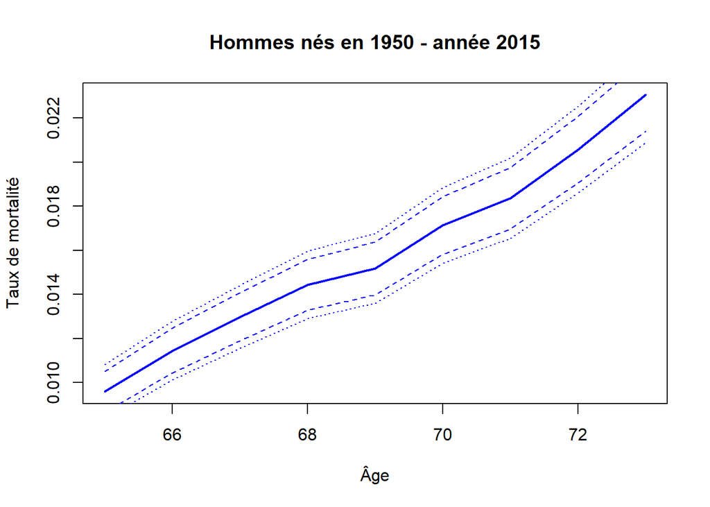

```r
# Hommes
plot(65:73, qx_male[, "2015"], type = "l", col = "blue", lwd = 2,
     ylab = "Taux de mortalité", xlab = "Âge", main = "Hommes nés en 1950 - année 2015")
lines(65:73, ic95_low_male[, "2015"], col = "blue", lty = 2)
lines(65:73, ic95_up_male[, "2015"], col = "blue", lty = 2)
lines(65:73, ic99_low_male[, "2015"], col = "blue", lty = 3)
lines(65:73, ic99_up_male[, "2015"], col = "blue", lty = 3)
```

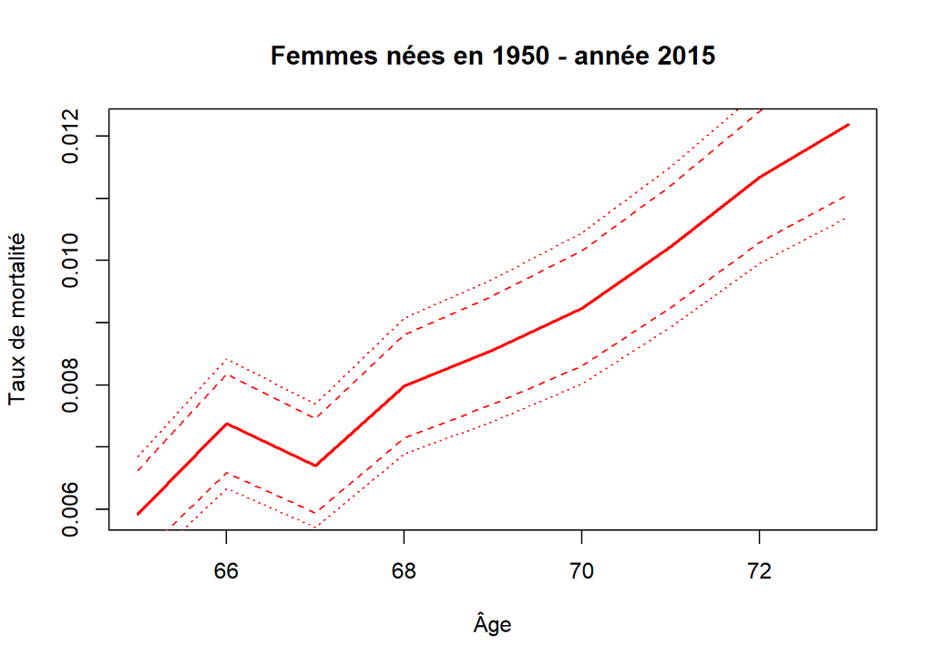

```r
plot(65:73, qx_female[, "2015"], type = "l", col = "red", lwd = 2,
     ylab = "Taux de mortalité", xlab = "Âge", main = "Femmes nées en 1950 - année 2015")
lines(65:73, ic95_low_female[, "2015"], col = "red", lty = 2)
lines(65:73, ic95_up_female[, "2015"], col = "red", lty = 2)
lines(65:73, ic99_low_female[, "2015"], col = "red", lty = 3)
lines(65:73, ic99_up_female[, "2015"], col = "red", lty = 3)
```

### (Question3) Estimer les paramètres d’un modèle de Lee-Carter

**Justifications

- **Choix de la plage d’âge** : 60 à 90 ans  
  → Âge où les tables sont bien observées, peu de bruit *(cours p. 43–44)*.
- **Choix de la période** : 1980 à l’année la plus récente  
  → Cohérence historique + suffisamment de points pour estimer les composantes temporelles.

```r
ages_fit <- 60:90
years_fit <- 1980:last_year

LCdata <- StMoMoData(
  data = CHEdata,
  series = "total",
  type = "central"
)
#ajustement du model (fitiing) :
LC33 <- lc(link = "logit" )
LCfit33 <- fit(LC33, data = central2initial(LCdata), ages.fit = ages_fit,  years.fit = years_fit)
```

```
## StMoMo: Start fitting with gnm
## Initialising
## Running start-up iterations..
## Running main iterations....
## Done
## StMoMo: Finish fitting with gnm
```

```r
# Effet âge alpha_x
LCfit33$ax
```

```
##        60        61        62        63        64        65        66        67
## -5.003785 -4.900675 -4.814524 -4.720726 -4.617151 -4.520462 -4.430295 -4.342948
##        68        69        70        71        72        73        74        75
## -4.250388 -4.155274 -4.064226 -3.964719 -3.860041 -3.750926 -3.644998 -3.546821
##        76        77        78        79        80        81        82        83
## -3.432743 -3.316827 -3.209822 -3.086273 -2.949508 -2.819051 -2.689938 -2.557074
##        84        85        86        87        88        89        90
## -2.430959 -2.302223 -2.161351 -2.031127 -1.907886 -1.769999 -1.629693
```

```r
# Sensibilité âge beta_x
LCfit33$bx
```

```
##             1
## 60 0.03611557
## 61 0.03446707
## 62 0.03556880
## 63 0.03578857
## 64 0.03419222
## 65 0.03505268
## 66 0.03523697
## 67 0.03597246
## 68 0.03543734
## 69 0.03587425
## 70 0.03633809
## 71 0.03582401
## 72 0.03586161
## 73 0.03674051
```

[output cut: 17 more lines]

```r
# Indice temporel k_t
LCfit33$kt
```

```
##       1980     1981     1982   1983     1984    1985    1986     1987     1988
## 1 13.20645 12.97885 11.61937 11.875 9.952842 9.77679 9.19836 8.067323 7.813568
##       1989     1990     1991     1992    1993   1994     1995     1996     1997
## 1 7.038032 7.981933 6.557672 5.787567 5.19743 4.1831 4.312816 3.441539 2.941743
##      1998     1999     2000      2001       2002       2003      2004      2005
## 1 2.45299 1.853276 1.290229 -0.134618 -0.5407751 -0.4461469 -2.583873 -2.831274
##        2006      2007      2008      2009      2010      2011      2012
## 1 -3.911067 -4.305886 -5.093327 -5.272263 -5.895411 -6.930402 -6.931952
##        2013      2014      2015      2016      2017      2018      2019
## 1 -7.308162 -8.541496 -7.584677 -9.541476 -9.550498 -10.21777 -10.51609
##        2020      2021      2022      2023
## 1 -7.635256 -10.12783 -9.819405 -11.80723
```

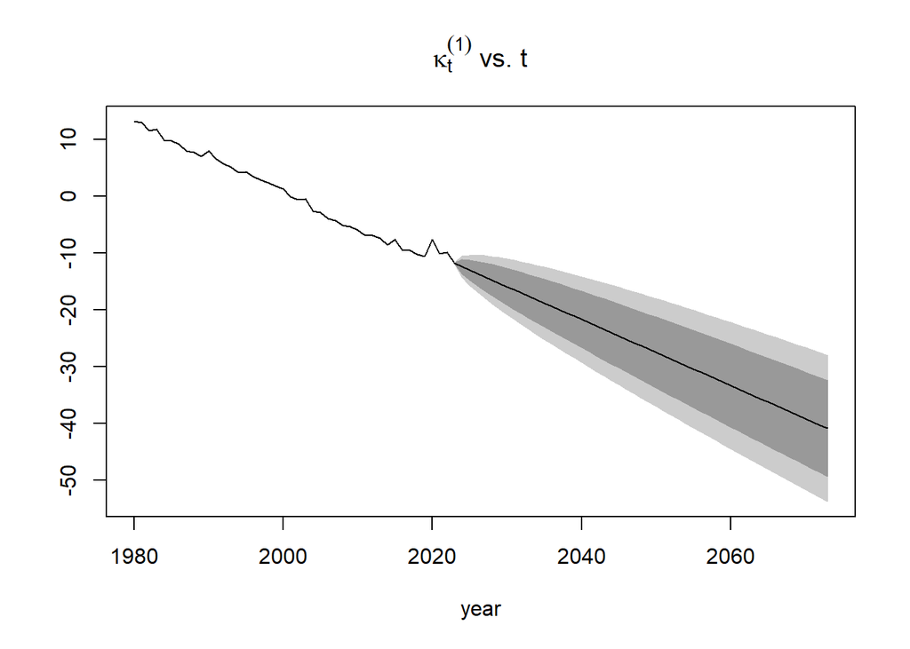

```r
projection <- forecast(LCfit33, years = 25)
plot(projection, only.kt=TRUE)
```

Analyse de la mortalité et projections

- **Évolution de** $k_t$ **dans le temps**  
  Depuis 1980, l’indice temporel $k_t$ diminue fortement, passant de **13.20** à **-7.63** en 2020.  
  → Cela traduit une **amélioration constante de la mortalité** en Suisse.  
  → La courbe correspondante descend régulièrement et se prolonge dans les projections futures, avec une **incertitude croissante visible dans le fan chart** (qui s’élargit légèrement).
- **Sensibilités par âge** ($b_x$)  
  Les âges entre **60 et 75 ans** sont les plus sensibles aux variations de $k_t$ (≈ 0.036).  
  → Aux âges plus avancés (90 ans), la sensibilité diminue (≈ 0.0179).
- **Interprétation**  
  Même si la mortalité générale baisse, **cette baisse a moins d’impact aux grands âges**, ce qui explique pourquoi la mortalité projetée reste élevée pour les âges avancés.
- **Recommandation**  
  Compte tenu de la diminution de $b_x$ et de l’incertitude croissante dans les projections pour les très grands âges,  
  → Il est **recommandé de fixer un âge maximum d’ajustement autour de 90 ans**.

### (Question4) Afficher les log taux de mortalités historiques des hommes et des femmes

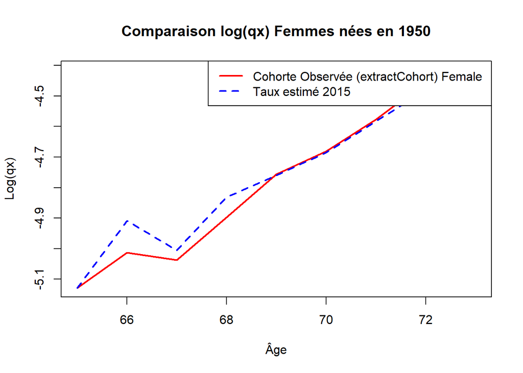

```r
# Extraction du taux de mortalité qx pour les femmes nées en 1950
log_qx_females_extract <- log(extractCohort(CHEdata$rate$female, cohort = 1950))

# Extraction du taux de mortalité qx pour les hommes nés en 1950
log_qx_males_extract <- log(extractCohort(CHEdata$rate$male, cohort = 1950))

# Tracé des taux observés (extraits par cohortes) et des taux estimés
ages_cohort <- 65:73  # correspond à la cohorte 1950 entre 2015 et 2023

plot(ages_cohort, log_qx_females_extract[names(qx_female[, "2015"])], type = "l", col = "red", lwd = 2,
     xlab = "Âge", ylab = "Log(qx)", main = "Comparaison log(qx) Femmes nées en 1950")
lines(ages_cohort, log(qx_female[, "2015"]), col = "blue", lwd = 2, lty = 2)
legend("topright", legend = c("Cohorte Observée (extractCohort) Female ", "Taux estimé 2015"), col = c("red", "blue"), lty = c(1, 2), lwd = 2)
```

Analyse du modèle Lee-Carter pour la cohorte féminine de 1950

Pourquoi prendre le log de $q_x$ ?

- Rend les **modèles linéaires applicables** (comme Lee-Carter)
- **Stabilise la variance** -️ **Facilite la visualisation**
- Respecte les **hypothèses théoriques** du modèle

Variables utilisées dans l’analyse

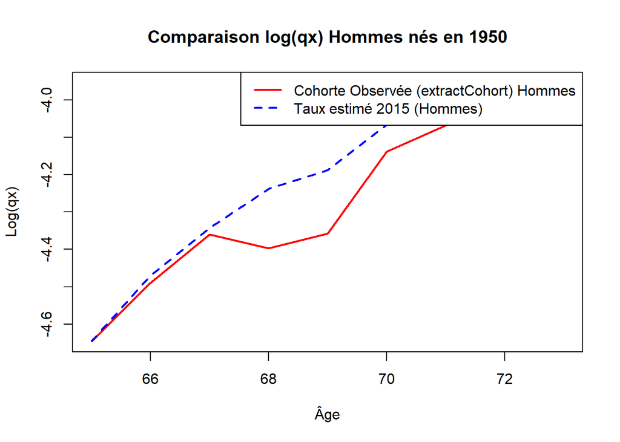

```r
plot(ages_cohort,
     log_qx_males_extract[names(qx_male[, "2015"])],
     type = "l", col = "red", lwd = 2,
     xlab = "Âge", ylab = "Log(qx)",
     main = "Comparaison log(qx) Hommes nés en 1950")

lines(ages_cohort,
      log(qx_male[, "2015"]),
      col = "blue", lwd = 2, lty = 2)

legend("topright",
       legend = c("Cohorte Observée (extractCohort) Hommes", "Taux estimé 2015 (Hommes)"),
       col = c("red", "blue"),
       lty = c(1, 2), lwd = 2)
```

### (Question5) Estimer la projection centrale (moyenne) sur 25 ans des taux de mortalité

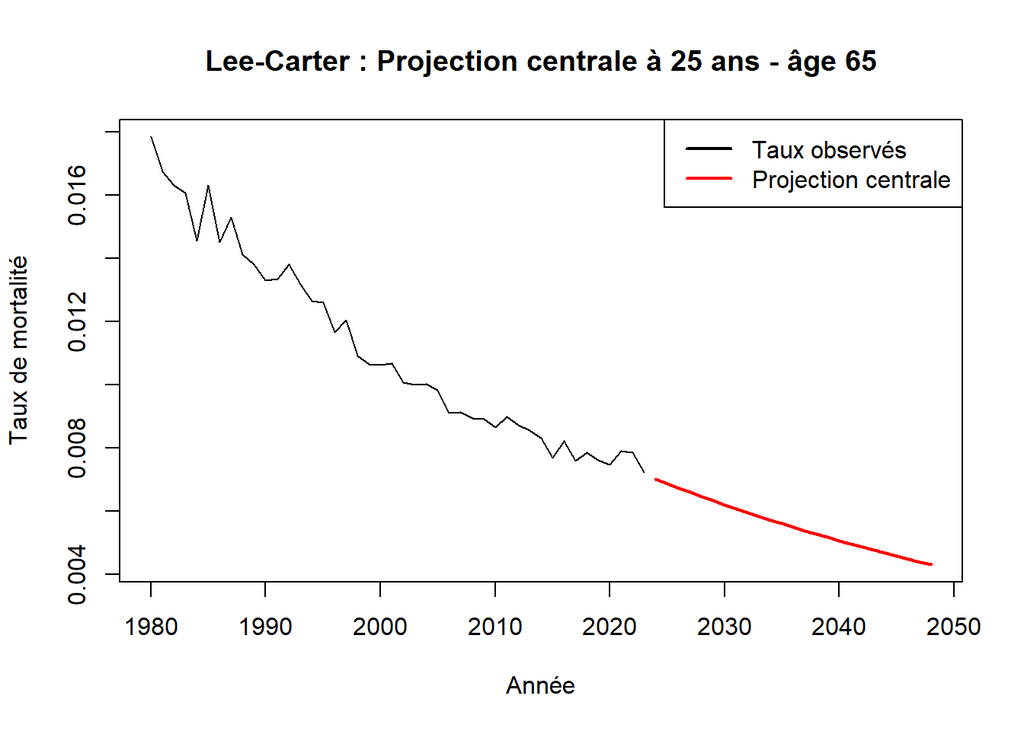

```r
# Projection centrale sur 25 ans
SuisseForecast <- forecast(LCfit33, h = 25)

# Taux observés
rates_mat <- LCfit33$Dxt / LCfit33$Ext

# Tracer les taux observés pour l'âge 65
plot(LCfit33$years, rates_mat["65", ],
     xlim = range(LCfit33$years, SuisseForecast$years),
     ylim = range(rates_mat["65", ], SuisseForecast$rates["65", ]),
     type = "l", xlab = "Année", ylab = "Taux de mortalité",
     main = "Lee-Carter : Projection centrale à 25 ans - âge 65")

# Ajouter la projection centrale (ligne rouge)
lines(SuisseForecast$years, SuisseForecast$rates["65", ], col = "red", lwd = 2)

legend("topright", legend = c("Taux observés", "Projection centrale"),
       col = c("black", "red"), lty = 1, lwd = 2)
```

** Interprétation du graphique de projection centrale des taux de mortalité à 65 ans

Ce graphique illustre l’évolution historique (en **noir**) et la projection centrale (en **rouge**) des taux de mortalité à l’âge de 65 ans,  
obtenue à partir du modèle de Lee-Carter.

La courbe rouge représente la trajectoire médiane ou attendue des taux de mortalité futurs,  
c’est-à-dire la projection sans simulation aléatoire, utilisant les valeurs prédites du paramètre temporel `k_t`.

On observe une poursuite de la baisse du taux de mortalité, en continuité avec la tendance passée,  
traduisant l’amélioration continue des conditions de vie, de la médecine et de la prévention.

Contrairement au graphique de simulation, ici il n’y a pas de bande d’incertitude :  
la projection centrale correspond à un scénario unique.

Cette projection est utile pour obtenir une vision moyenne de l’évolution attendue,  
bien qu’elle ne reflète pas la variabilité possible de la mortalité future.

Elle constitue néanmoins une base solide pour des hypothèses actuarielles prudentes.

Ce type de projection est particulièrement important dans la tarification et la provision des rentes viagères,  
où une sous-estimation des gains de longévité peut entraîner un risque financier important pour l’assureur.

**tracer plusieurs trajectoires simulées

[figure not shown]

```r
# Projections simulées sur 25 ans
SuisseSim <- simulate(LCfit33, h = 25, nsim = 5000)

# Taux observés
rates_mat <- LCfit33$Dxt / LCfit33$Ext

# Tracer les taux observés pour l'âge 65
plot(LCfit33$years, rates_mat["65", ],
     xlim = range(LCfit33$years, SuisseSim$years),
     ylim = range(rates_mat["65", ], SuisseSim$rates["65", , ]),
     type = "l", xlab = "Année", ylab = "Taux de mortalité",
     main = "Lee-Carter : Taux de mortalité simulés à partir de 2005 - âge 65")

# Ajouter les 5000 trajectoires simulées
matlines(SuisseSim$years, SuisseSim$rates["65", , ], type = "l", lty = 1)
```

** Simulation des taux de mortalité à 65 ans selon le modèle Lee-Carter

- Interprétation du graphique :

On observe une tendance globale à la baisse des taux de mortalité dans la zone simulée,  
ce qui reflète l’amélioration attendue de la longévité dans les années à venir.

La dispersion des trajectoires simulées traduit l’incertitude inhérente aux projections stochastiques du modèle Lee-Carter,  
en tenant compte de la variabilité aléatoire dans l’évolution de la composante temporelle `k_t`.

Cette incertitude est cruciale pour la tarification des rentes viagères :  
les assureurs doivent anticiper non seulement une baisse probable des taux de mortalité,  
mais aussi la possibilité de scénarios plus ou moins favorables à la longévité.

Enfin, le fait que les trajectoires simulées restent relativement regroupées indique que le modèle est stable  
et que les paramètres estimés fournissent une base fiable pour la projection de la mortalité future à cet âge spécifique.

```r
# Probabilités pour les intervalles du fan chart
probs <- c(2.5, 10, 25, 50, 75, 90, 97.5)

#50% → la médiane (le scénario central),
#2.5% et 97.5% → bordures de l’intervalle de confiance à 95%,
#10% et 90% → intervalle de confiance à 80%,
#25% et 75% → intervalle à 50%.

# Calcul des taux observés
qxt <- LCfit33$Dxt / LCfit33$Ext

# Taux simulés pour l'âge 65
sim_rates_65 <- t(SuisseSim$rates["65", , ])  # transpose car matplot veut les colonnes
```

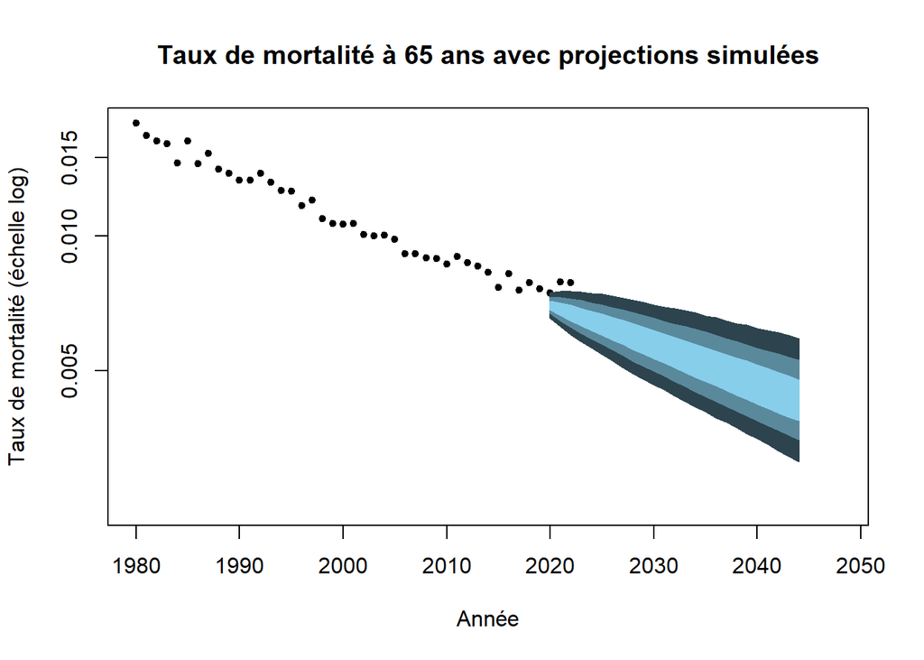

```r
# Plot des taux observés (sur échelle log)
matplot(LCfit33$years, qxt["65", ],
        xlim = c(1980, 2048),
        ylim = c(min(qxt["65", ], sim_rates_65), max(qxt["65", ], sim_rates_65)),
        pch = 20, col = "black", log = "y",
        xlab = "Année", ylab = "Taux de mortalité (échelle log)",
        main = "Taux de mortalité à 65 ans avec projections simulées")
# Ajout du fan chart à partir de 2020
library(fanplot)
fan(sim_rates_65, start = 2020, probs = probs,
    n.fan = 4,
    fan.col = colorRampPalette(c("skyblue", "black")),
    ln = NULL)
```

### (Question7) l’expression de l’espérance de vie résiduelle (cohorte) à un âge x ∈ N

```r
dim(SuisseSim$rates)
```

```
## [1]   31   25 5000
```

```r
# exemple possible : (âges, années, nsim)


mean_rates <- apply(SuisseSim$rates, c(1, 2), mean)  # moyenne sur la 3e dimension
year_proj <- 2040
year_index <- which(SuisseSim$years == year_proj)

# Calcul de l'espérance de vie résiduelle
e65 <- 0
prod_surv <- 1
mu_proj <- mean_rates[, year_index]  # vecteur taux par âge pour 2040
ages_proj <- as.numeric(rownames(mean_rates))
mu_65plus <- mu_proj[ages_proj >= 65]
for (i in seq_along(mu_65plus)) {
  p_surv <- exp(-mu_65plus[i])
  e65 <- e65 + prod_surv
  prod_surv <- prod_surv * p_surv
}

print(paste("Espérance de vie résiduelle à 65 ans en", year_proj, ":", round(e65, 2), "années"))
```

```
## [1] "Espérance de vie résiduelle à 65 ans en 2040 : 21.86 années"
```

### (Question8) calcul de la valeur actuelle probable du contrat

```r
calc_VAP<- function(qx, r = 0.03) {
  n <- length(qx)
  v <- 1 / (1 + r)
  px <- cumprod(c(1, 1 - qx[-n]))  # probabilité de survie à chaque année

  vap <- sum(v^(0:(n-1)) * px)  # somme actualisée des probabilités de survie
  return(vap)
}
```

Choix du taux d’actualisation : pourquoi 0.03 ?

**0.03 = 3% par an**  
C’est un taux d’actualisation **couramment utilisé**, notamment :

- Comme **taux sans risque**, proche des **rendements des obligations d’État** ;
- Comme **approximation d’un taux moyen** dans les **calculs actuariels**.

Ce taux *n’est pas une valeur fixe obligatoire*.  
Il est souvent choisi **par convention dans les exercices pédagogiques**.

En pratique, ce taux dépend de plusieurs facteurs :  
- **La politique de l’entreprise**  
*Exemple* : taux technique utilisé en **assurance vie**.  
- **Les conditions économiques**  
*Exemple* : taux d’intérêt du **marché à long terme**.

### (Question9) Calcul de la VAP

```r
#Chaque assuré a contracté un contrat de rente viagère temporaire en 2015
qx_male_65 <- qx_male[as.character(65:(65 + ncol(qx_male) - 1)), "2015"]
qx_female_65 <- qx_female[as.character(65:(65 + ncol(qx_female) - 1)), "2015"]

vap_male <- calc_VAP(qx_male_65)
vap_female <- calc_VAP(qx_female_65)

print(qx_male_65)
```

```
##       65       66       67       68       69       70       71       72
## 0.009600 0.011458 0.012993 0.014440 0.015178 0.017138 0.018371 0.020569
##       73
## 0.023053
```

```r
print(qx_female_65)
```

```
##       65       66       67       68       69       70       71       72
## 0.005921 0.007381 0.006703 0.007981 0.008562 0.009231 0.010225 0.011345
##       73
## 0.012184
```

```r
cat("VAP Homme :", vap_male, "\n")
```

```
## VAP Homme : 7.631432
```

```r
cat("VAP Femme :", vap_female, "\n")
```

```
## VAP Femme : 7.793868
```

**Interprétation de la VAP et différences selon le genre

**Plus la VAP est élevée**, plus le **coût ou la valeur du contrat** est important.  
→ Cela signifie que l’assuré a **plus de chances de vivre longtemps**,  
et donc que le contrat devra **potentiellement verser une rente pendant une période plus longue**.

**Les femmes ont des taux de mortalité plus faibles** (moins de décès chaque année),  
ce qui implique une **espérance de vie plus longue**.

➡La rente doit donc être versée plus longtemps,  
ce qui **augmente la valeur actuelle** du contrat (VAP).

**Conclusion** : la **VAP féminine est légèrement supérieure** à la VAP masculine,  
en raison de cette espérance de vie plus élevée.

### (Question10) Un assureur peut-il différencier ses tarifs selon le genre de ses assurés ?

### Différenciation des tarifs selon le genre

**Oui, un assureur peut différencier ses tarifs selon le genre de ses assurés.**

Justification :

- **Les tables de mortalité** montrent une différence significative entre hommes et femmes :  
  → **Les femmes vivent généralement plus longtemps.**
- Cette différence impacte directement le **coût des contrats d’assurance vie ou de rentes viagères** :  
  → Les femmes ont une **espérance de vie plus longue**, donc une **valeur actuelle probable (VAP)** plus élevée.
- Par conséquent, **les primes ne seront pas les mêmes** entre hommes et femmes pour **couvrir le même risque**.
- Cette différenciation permet à l’assureur de **mieux ajuster ses tarifs au risque réel**,  
  assurant ainsi **l’équilibre financier du produit**.

```r
# Extraction des qx totaux à partir de l'âge 65 pour l'année 2015
# Calcul du taux total (hommes + femmes) pondéré par exposition
qx_total <- (qx_male * exposure_male + qx_female * exposure_female) / (exposure_male + exposure_female)

# Extraction des âges >= 65 pour 2015
ages <- as.numeric(rownames(qx_total))
qx_total_65 <- qx_total[as.character(ages[ages >= 65]), "2015"]

# Calcul de la VAP globale
vap_total <- calc_VAP(qx_total_65)

cat("VAP Population globale :", vap_total, "\n")
```

```
## VAP Population globale : 7.714943
```

Valeurs actuelles probables (VAP)

- **VAP Homme** : 7.631432
- **VAP Femme** : 7.793868
- **VAP Globale** : 7.714943

Interprétation :

La **VAP globale** se situe **bien entre la VAP homme et la VAP femme**, ce qui est **parfaitement cohérent**.

> En effet, la VAP globale est une **moyenne pondérée** des deux valeurs selon la répartition hommes/femmes.  
> Elle doit donc **logiquement être comprise entre les deux extrêmes**.

### (Question11) une autre méthode de tarification unisexe adapté au portefeuille de l’assureur

Proposition : Tarification unisexe pondérée selon la composition du portefeuille Principe : Construire une table de mortalité synthétique à partir des taux projetés : unisexe Calcul de la prime : Utiliser cette table pondérée pour estimer l’espérance de vie résiduelle et donc la valeur actuelle probable (VAP) de la rente viagère unisexe.

```r
# Calcul de la table mixte (hommes + femmes pondérés par l'exposition)
qx_mixte <- (qx_male * exposure_male + qx_female * exposure_female) / (exposure_male + exposure_female)

# Fonction pour ajuster l'âge (exemple : âge pivot = 1 an pour les femmes, -2 ans pour les hommes)
tarif_unisexe <- function(age, sexe) {
  age_ajuste <- if (sexe == "F") age + 1 else age - 2

  if (!as.character(age_ajuste) %in% rownames(qx_mixte)) {
    warning(paste("Âge ajusté", age_ajuste, "non présent."))
    return(NA)
  }

  age_fin <- min(age_ajuste + 29, age_max_dispo)
  ages_vec <- as.character(age_ajuste:age_fin)
  ages_vec <- ages_vec[ages_vec %in% rownames(qx_mixte)]

  qx_vect <- qx_mixte[ages_vec, "2015"]
  calc_VAP(qx_vect)
}

age_max_dispo <- max(as.numeric(rownames(qx_mixte)))

primes_pures_F <- sapply(ages, function(a) {
  age_fin <- min(a + 29, age_max_dispo)
  qx_vect <- qx_female[as.character(a:age_fin), "2015"]
  qx_vect <- qx_vect[!is.na(qx_vect)]
  calc_VAP(qx_vect)
})

primes_unisexe_F <- sapply(ages, function(a) {
  tarif_unisexe(a, "F")
})
primes_pures_H <- sapply(ages, function(a) {
  age_fin <- min(a + 29, age_max_dispo)
  qx_vect <- qx_male[as.character(a:age_fin), "2015"]
  qx_vect <- qx_vect[!is.na(qx_vect)]
  calc_VAP(qx_vect)
})
```

```r
# Calcul primes unisexes hommes (avec ajustement âge -2)
primes_unisexe_H <- sapply(ages, function(a) {
  tarif_unisexe(a, "H")
})
```

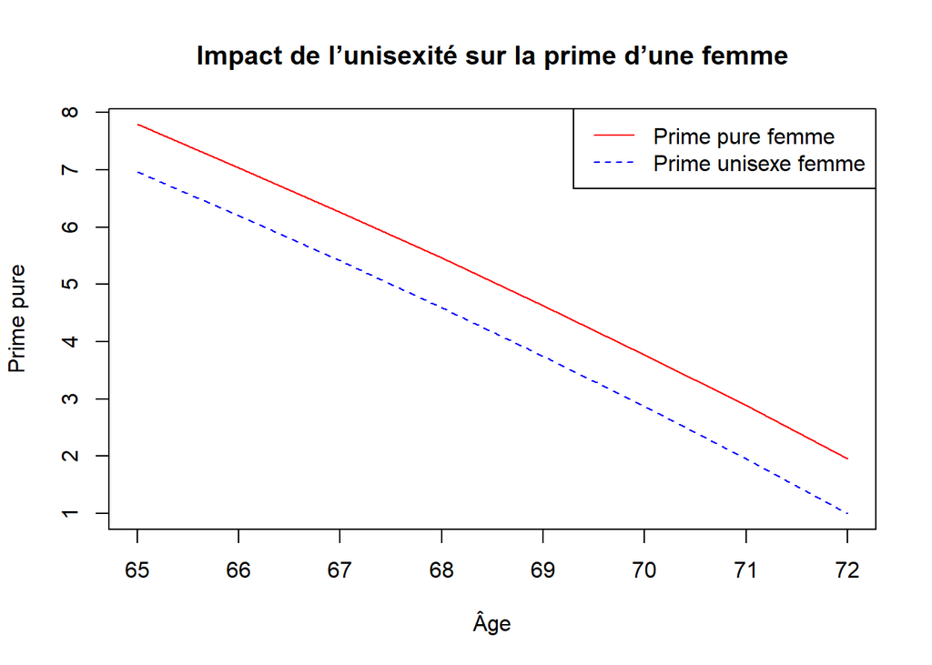

```r
# Nettoyage
valid_idx <- is.finite(primes_pures_F) & is.finite(primes_unisexe_F)

# Tracé corrigé
plot(ages[valid_idx], primes_pures_F[valid_idx], type = "l", col = "red",
     ylim = range(c(primes_pures_F[valid_idx], primes_unisexe_F[valid_idx])),
     main = "Impact de l’unisexité sur la prime d’une femme",
     ylab = "Prime pure", xlab = "Âge")

lines(ages[valid_idx], primes_unisexe_F[valid_idx], col = "blue", lty = 2)
legend("topright", legend = c("Prime pure femme", "Prime unisexe femme"),
       col = c("red", "blue"), lty = c(1, 2))
```

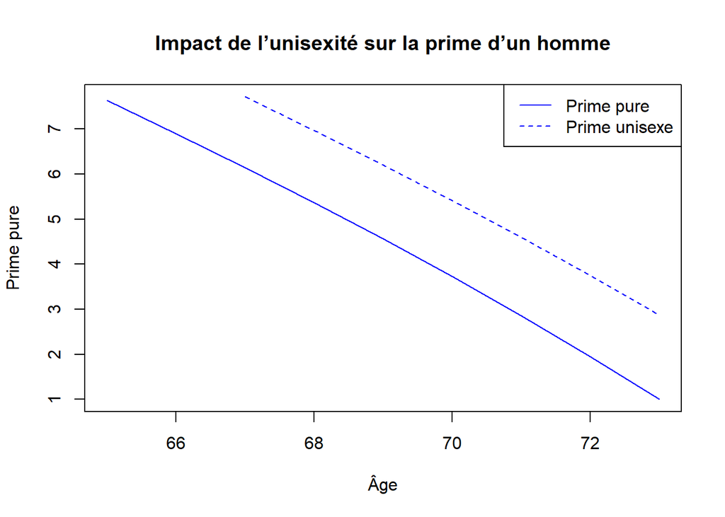

```r
# Plot pour un homme : Prime pure vs Prime unisexe
plot(ages, primes_pures_H, type = "l", col = "blue",
     ylim = range(c(primes_pures_H, primes_unisexe_H), na.rm = TRUE),
     main = "Impact de l’unisexité sur la prime d’un homme",
     ylab = "Prime pure", xlab = "Âge")

lines(ages, primes_unisexe_H, col = "blue", lty = 2)
legend("topright", legend = c("Prime pure", "Prime unisexe"), col = "blue", lty = 1:2)
```

```r
##ecarts###
ecart_F <- primes_unisexe_F - primes_pures_F
ecart_H <- primes_unisexe_H - primes_pures_H
resultats <- data.frame(
  Age = ages,
  Prime_pure_F = primes_pures_F,
  Prime_unisexe_F = primes_unisexe_F,
  Ecart_F = ecart_F,
  Prime_pure_H = primes_pures_H,
  Prime_unisexe_H = primes_unisexe_H,
  Ecart_H = ecart_H
)

print(resultats)
```

```
##   Age Prime_pure_F Prime_unisexe_F    Ecart_F Prime_pure_H Prime_unisexe_H
## 1  65     7.793868        6.970173 -0.8236942     7.631432              NA
## 2  66     7.039364        6.207352 -0.8320113     6.896582              NA
## 3  67     6.266800        5.416333 -0.8504670     6.143876        7.714943
## 4  68     5.461412        4.599854 -0.8615573     5.367938        6.970173
## 5  69     4.632224        3.751939 -0.8802846     4.564893        6.207352
## 6  70     3.773499        2.871916 -0.9015835     3.728430        5.416333
## 7  71     2.883320        1.955630 -0.9276901     2.859285        4.599854
## 8  72     1.959859        1.000000 -0.9598592     1.950904        3.751939
## 9  73     1.000000              NA         NA     1.000000        2.871916
##    Ecart_H
## 1       NA
## 2       NA
## 3 1.571068
## 4 1.602236
## 5 1.642459
## 6 1.687903
## 7 1.740569
## 8 1.801035
## 9 1.871916
```

** Transfert de risque entre les sexes avec tarif unisexe

Ce que nous observons ici, c’est un **transfert de risque entre les sexes** :

Pour les femmes :  
- Le **tarif unisexe** diminue la prime par rapport à leur **prime pure**.  
- ➤ Elles **paient moins** que ce que leur risque réel justifierait.  
- ➤ Elles **bénéficient d’un transfert de risque positif**, car une partie de leur risque est assumée par les hommes.

Pour les hommes :  
- Le **tarif unisexe** augmente la prime par rapport à leur **prime pure**.  
- ➤ Ils **paient plus** que ce que leur risque réel impliquerait.  
- ➤ Ils **subissent un transfert de risque négatif**, car ils financent une partie du risque féminin.

En résumé :  
Ce **transfert de risque** agit comme une **mutualisation** : - Les hommes **“subventionnent” partiellement** les femmes. - Les femmes **“profitent” de cette mutualisation**, avec un coût réduit.